# Study 2a: Between-Subject Manipulation of Wording

Bartosz Maćkiewicz, Katarzyna Kuś, Katarzyna Paprzycka‑Hausman, Marta Zaręba

### Simplified Codebook

- **participant** – Anonymous numeric identifier, unique per participant.
- **PROLIFIC** – Anonymous identifier assigned by Prolific, unique per participant.
- **startdate** – The exact date and time the participant started the survey.
- **submitdate** – The exact date and time the participant finished the survey.
- **att** – Answer to the attention check question. “A5” is the correct response.
- **condition** – Vignette type manipulated between-subjects: Harm (CEO’s program harms the environment) or Help (CEO’s program helps the environment).
- **form**– Wording of the knowledge question, manipulated between-subjects:
  - `ST`: Change-of-state formulation (“…knew that the environment would be harmed.”)
  - `CA`: Causal formulation (“…knew that implementing the new program would harm the environment.”)
  - `AG`: Agentive formulation (“…knew that he would harm the environment.”)
- **Kc** – Agreement with the knowledge attribution statement, answered on a 7-point Likert scale from -3 (Strongly disagree) to +3 (Strongly agree).
- **KcJust** – Justification for the knowledge attribution response.
  - (`AGB`) The CEO believed that [side effect would occur].
  - (`AGA`) The CEO was aware that [side effect could occur].
  - (`AGR`) The CEO had reasons to believe that [side effect would occur].
  - (`-oth-`) Other (please specify).
- **IntChair** – Binary answer to the question “Did the CEO intentionally [harm/help] the environment?”.
- **KNominal** – The `Kc` variable converted into three categories: `Disagree` (`Kc` < 0), `Agree` (`Kc` > 0), and `Hesitate` (`Kc` = 0).

# Demographics

A total of 589 participants were included in the final analysis (600 participants were recruited before applying the attention check). The sample’s average age was M = 42.43 (SD = 13.21). The sample included 290 females, 296 males, and 3 individuals who did not disclose their gender.

# Knowledge Attributions

This section analyzes responses to the question about the CEO’s knowledge, based on three different phrasings:

To what extent do you agree with the following claims:

- **[CA] (Causal)** The CEO knew that implementing the new program would harm the environment.
- **[AG] (Agentive)** The CEO knew that he would harm the environment.
- **[ST] (Change of state)** The CEO knew that the environment would be harmed.

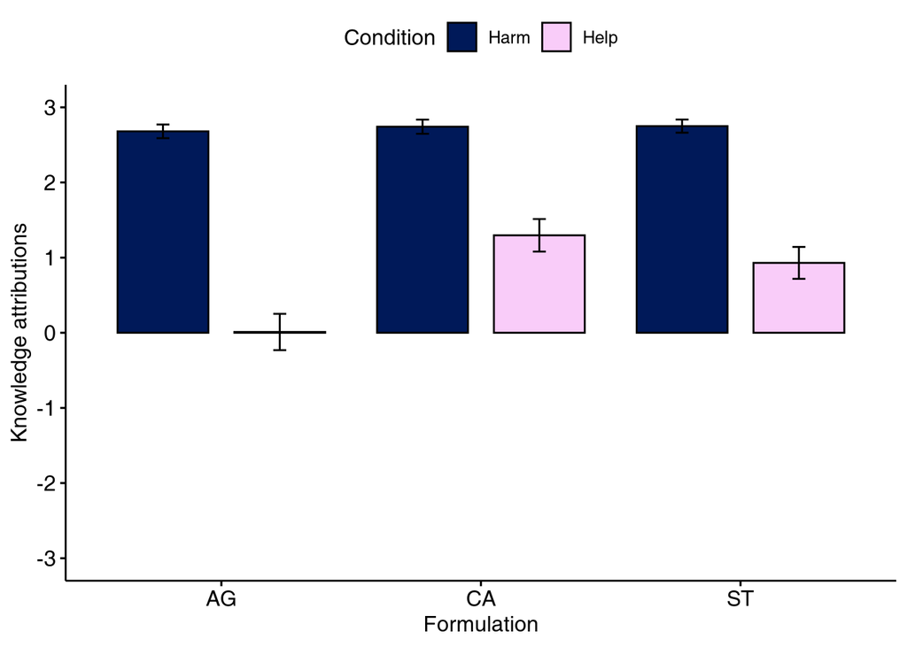

## Descriptive statistics

| form | condition | M | SD | n |
| --- | --- | --- | --- | --- |
| AG | Harm | 2.68 | 0.91 | 100 |
| AG | Help | 0.01 | 2.35 | 95 |
| CA | Harm | 2.74 | 0.93 | 97 |
| CA | Help | 1.30 | 2.18 | 101 |
| ST | Harm | 2.75 | 0.86 | 96 |
| ST | Help | 0.93 | 2.12 | 100 |

## ANOVA

| Effect | DFn | DFd | F | p | p<.05 | ges |
| --- | --- | --- | --- | --- | --- | --- |
| condition | 1 | 583 | 199.9 | 3.131e-39 | * | 0.2553 |
| form | 2 | 583 | 8.199 | 0.0003078 | * | 0.02736 |
| condition:form | 2 | 583 | 6.711 | 0.001314 | * | 0.0225 |

## Pairwise t-tests (by Condition)

### Harm Condition

| .y. | group1 | group2 | n1 | n2 | p | p.signif | p.adj | p.adj.signif |
| --- | --- | --- | --- | --- | --- | --- | --- | --- |
| Kc | AG | CA | 100 | 97 | 0.63 | ns | 1.00 | ns |
| Kc | AG | ST | 100 | 96 | 0.59 | ns | 1.00 | ns |
| Kc | CA | ST | 97 | 96 | 0.95 | ns | 1.00 | ns |

### Help Condition

| .y. | group1 | group2 | n1 | n2 | p | p.signif | p.adj | p.adj.signif |
| --- | --- | --- | --- | --- | --- | --- | --- | --- |
| Kc | AG | CA | 95 | 101 | 0.00 |  | 0.00 | *** |
| Kc | AG | ST | 95 | 100 | 0.00 |  | 0.01 |  |
| Kc | CA | ST | 101 | 100 | 0.24 | ns | 0.24 | ns |

# Intentionality Judgments

This section analyzes responses to the question: *Did the CEO intentionally [harm/help] the environment?*

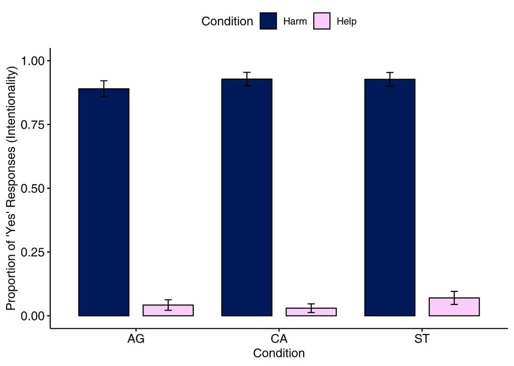

## Descriptive Statistics

| condition | form | M | SD | n |
| --- | --- | --- | --- | --- |
| Harm | AG | 0.89 | 0.31 | 100 |
| Harm | CA | 0.93 | 0.26 | 97 |
| Harm | ST | 0.93 | 0.26 | 96 |
| Help | AG | 0.04 | 0.20 | 95 |
| Help | CA | 0.03 | 0.17 | 101 |
| Help | ST | 0.07 | 0.26 | 100 |

# Justification Analysis

This section provides an exploratory analysis of the justifications participants gave for their knowledge attributions.

## Justifications by Knowledge Attribution (`Agree`, `Disagree`, `Hesitate`)

Here, we explore justification patterns separately for participants who agreed, disagreed, or hesitated about the CEO’s knowledge.

### Percentages

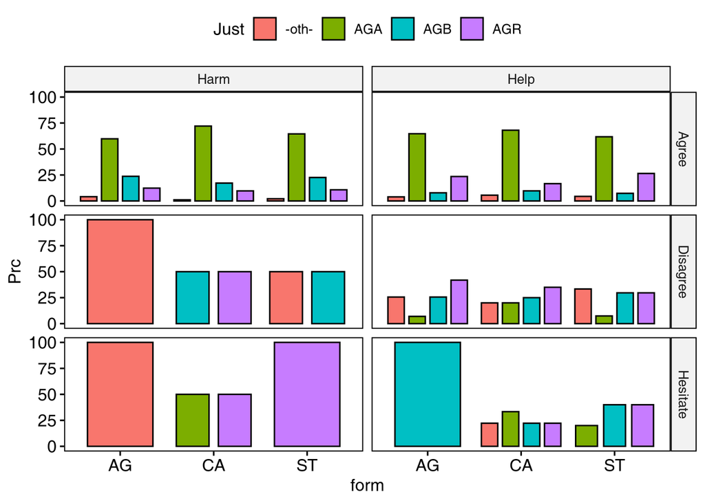

### Counts

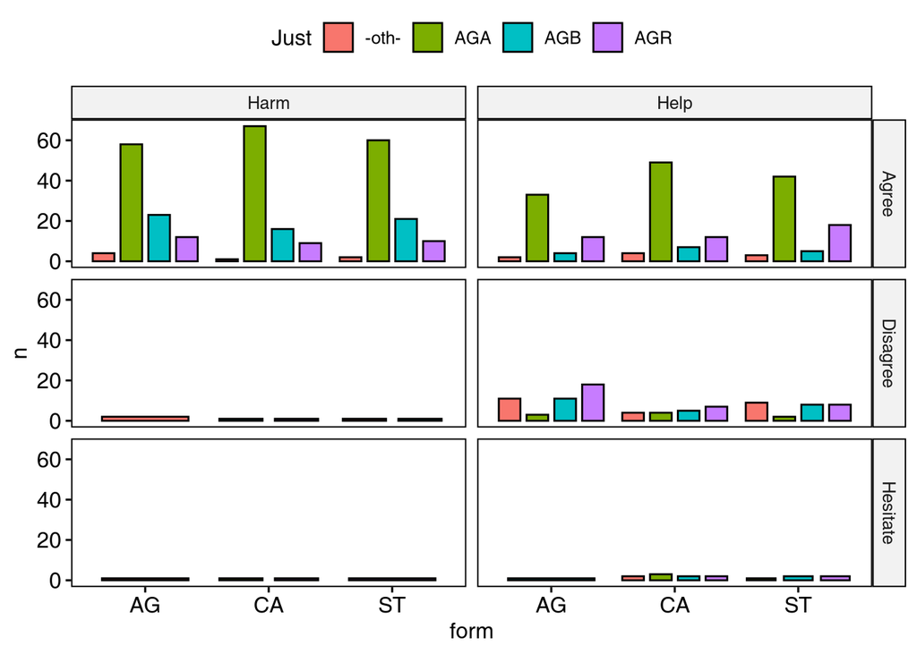

| form | condition | K | Just | Prc | n |
| --- | --- | --- | --- | --- | --- |
| AG | Harm | Agree | -oth- | 4.12 | 4 |
| AG | Harm | Agree | AGA | 59.79 | 58 |
| AG | Harm | Agree | AGB | 23.71 | 23 |
| AG | Harm | Agree | AGR | 12.37 | 12 |
| AG | Harm | Disagree | -oth- | 100.00 | 2 |
| AG | Harm | Hesitate | -oth- | 100.00 | 1 |
| AG | Help | Agree | -oth- | 3.92 | 2 |
| AG | Help | Agree | AGA | 64.71 | 33 |
| AG | Help | Agree | AGB | 7.84 | 4 |
| AG | Help | Agree | AGR | 23.53 | 12 |
| AG | Help | Disagree | -oth- | 25.58 | 11 |
| AG | Help | Disagree | AGA | 6.98 | 3 |
| AG | Help | Disagree | AGB | 25.58 | 11 |
| AG | Help | Disagree | AGR | 41.86 | 18 |
| AG | Help | Hesitate | AGB | 100.00 | 1 |
| CA | Harm | Agree | -oth- | 1.08 | 1 |
| CA | Harm | Agree | AGA | 72.04 | 67 |
| CA | Harm | Agree | AGB | 17.20 | 16 |
| CA | Harm | Agree | AGR | 9.68 | 9 |
| CA | Harm | Disagree | AGB | 50.00 | 1 |
| CA | Harm | Disagree | AGR | 50.00 | 1 |
| CA | Harm | Hesitate | AGA | 50.00 | 1 |
| CA | Harm | Hesitate | AGR | 50.00 | 1 |
| CA | Help | Agree | -oth- | 5.56 | 4 |
| CA | Help | Agree | AGA | 68.06 | 49 |
| CA | Help | Agree | AGB | 9.72 | 7 |
| CA | Help | Agree | AGR | 16.67 | 12 |
| CA | Help | Disagree | -oth- | 20.00 | 4 |
| CA | Help | Disagree | AGA | 20.00 | 4 |
| CA | Help | Disagree | AGB | 25.00 | 5 |
| CA | Help | Disagree | AGR | 35.00 | 7 |
| CA | Help | Hesitate | -oth- | 22.22 | 2 |
| CA | Help | Hesitate | AGA | 33.33 | 3 |
| CA | Help | Hesitate | AGB | 22.22 | 2 |
| CA | Help | Hesitate | AGR | 22.22 | 2 |
| ST | Harm | Agree | -oth- | 2.15 | 2 |
| ST | Harm | Agree | AGA | 64.52 | 60 |
| ST | Harm | Agree | AGB | 22.58 | 21 |
| ST | Harm | Agree | AGR | 10.75 | 10 |
| ST | Harm | Disagree | -oth- | 50.00 | 1 |
| ST | Harm | Disagree | AGB | 50.00 | 1 |
| ST | Harm | Hesitate | AGR | 100.00 | 1 |
| ST | Help | Agree | -oth- | 4.41 | 3 |
| ST | Help | Agree | AGA | 61.76 | 42 |
| ST | Help | Agree | AGB | 7.35 | 5 |
| ST | Help | Agree | AGR | 26.47 | 18 |
| ST | Help | Disagree | -oth- | 33.33 | 9 |
| ST | Help | Disagree | AGA | 7.41 | 2 |
| ST | Help | Disagree | AGB | 29.63 | 8 |
| ST | Help | Disagree | AGR | 29.63 | 8 |
| ST | Help | Hesitate | AGA | 20.00 | 1 |
| ST | Help | Hesitate | AGB | 40.00 | 2 |
| ST | Help | Hesitate | AGR | 40.00 | 2 |

## Justifications (Aggregated Across Knowledge Attributions)

Here, we collapse across the `Agree`/`Disagree`/`Hesitate` categories to see the overall justification patterns.

### Percentages

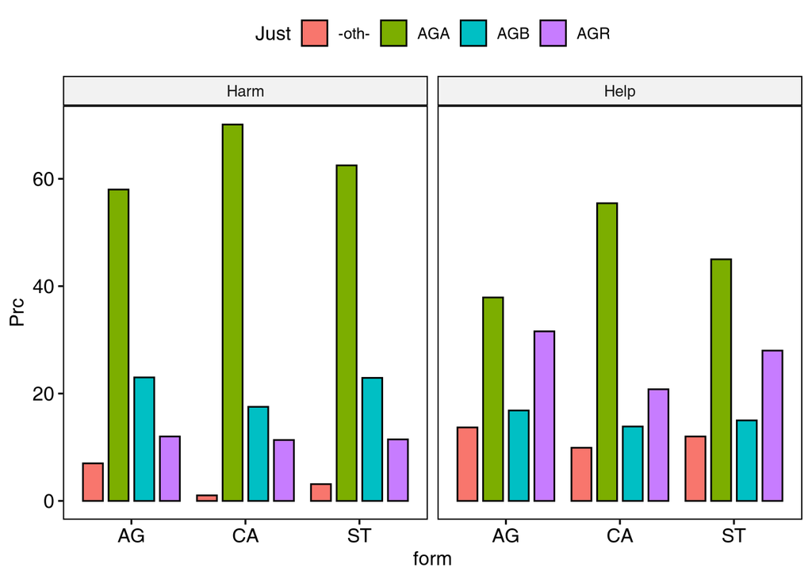

### Counts

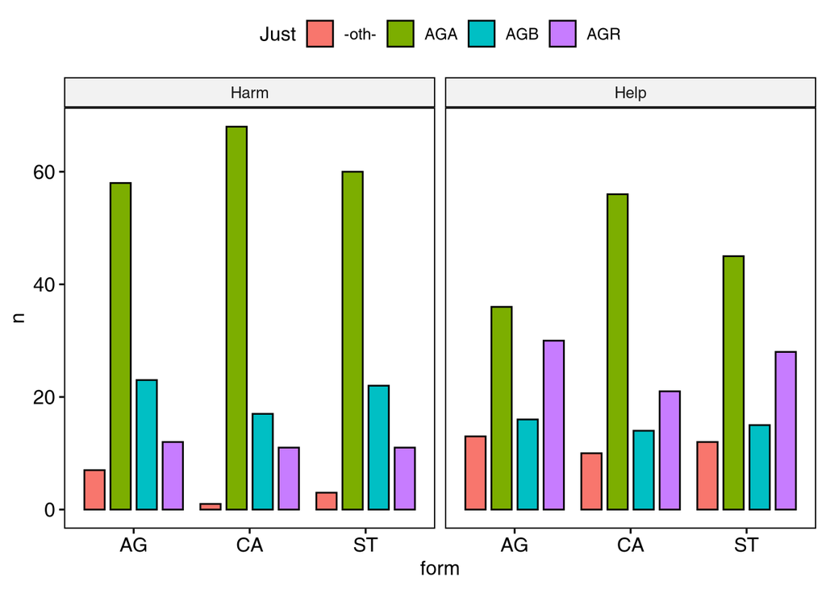

| form | condition | Just | Prc | n |
| --- | --- | --- | --- | --- |
| AG | Harm | -oth- | 7.00 | 7 |
| AG | Harm | AGA | 58.00 | 58 |
| AG | Harm | AGB | 23.00 | 23 |
| AG | Harm | AGR | 12.00 | 12 |
| AG | Help | -oth- | 13.68 | 13 |
| AG | Help | AGA | 37.89 | 36 |
| AG | Help | AGB | 16.84 | 16 |
| AG | Help | AGR | 31.58 | 30 |
| CA | Harm | -oth- | 1.03 | 1 |
| CA | Harm | AGA | 70.10 | 68 |
| CA | Harm | AGB | 17.53 | 17 |
| CA | Harm | AGR | 11.34 | 11 |
| CA | Help | -oth- | 9.90 | 10 |
| CA | Help | AGA | 55.45 | 56 |
| CA | Help | AGB | 13.86 | 14 |
| CA | Help | AGR | 20.79 | 21 |
| ST | Harm | -oth- | 3.12 | 3 |
| ST | Harm | AGA | 62.50 | 60 |
| ST | Harm | AGB | 22.92 | 22 |
| ST | Harm | AGR | 11.46 | 11 |
| ST | Help | -oth- | 12.00 | 12 |
| ST | Help | AGA | 45.00 | 45 |
| ST | Help | AGB | 15.00 | 15 |
| ST | Help | AGR | 28.00 | 28 |

## Justifications (Aggregated Across Formulations)

### Percentages

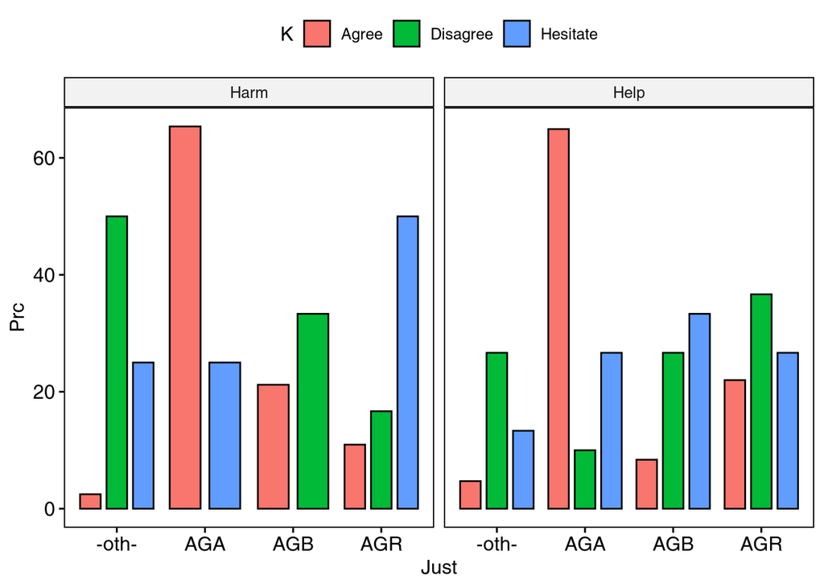

### Counts

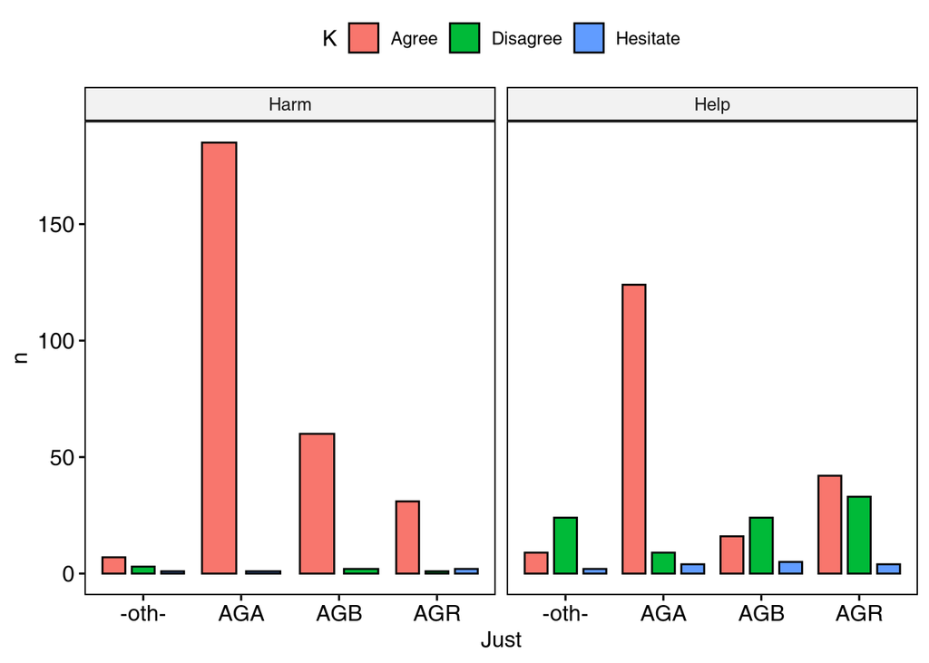

| condition | K | Just | Prc | n |
| --- | --- | --- | --- | --- |
| Harm | Agree | -oth- | 2.47 | 7 |
| Harm | Agree | AGA | 65.37 | 185 |
| Harm | Agree | AGB | 21.20 | 60 |
| Harm | Agree | AGR | 10.95 | 31 |
| Harm | Disagree | -oth- | 50.00 | 3 |
| Harm | Disagree | AGB | 33.33 | 2 |
| Harm | Disagree | AGR | 16.67 | 1 |
| Harm | Hesitate | -oth- | 25.00 | 1 |
| Harm | Hesitate | AGA | 25.00 | 1 |
| Harm | Hesitate | AGR | 50.00 | 2 |
| Help | Agree | -oth- | 4.71 | 9 |
| Help | Agree | AGA | 64.92 | 124 |
| Help | Agree | AGB | 8.38 | 16 |
| Help | Agree | AGR | 21.99 | 42 |
| Help | Disagree | -oth- | 26.67 | 24 |
| Help | Disagree | AGA | 10.00 | 9 |
| Help | Disagree | AGB | 26.67 | 24 |
| Help | Disagree | AGR | 36.67 | 33 |
| Help | Hesitate | -oth- | 13.33 | 2 |
| Help | Hesitate | AGA | 26.67 | 4 |
| Help | Hesitate | AGB | 33.33 | 5 |
| Help | Hesitate | AGR | 26.67 | 4 |

| condition | Kc | Percent_B | n_B | Percent_A | n_A | Percent_R | n_R | Percent_O | n_O |
| --- | --- | --- | --- | --- | --- | --- | --- | --- | --- |
| Harm | Agree | 21.20 | 60 | 65.37 | 185 | 10.95 | 31 | 2.47 | 7 |
| Harm | Disagree | 33.33 | 2 |  |  | 16.67 | 1 | 50.00 | 3 |
| Harm | Hesitate |  |  | 25.00 | 1 | 50.00 | 2 | 25.00 | 1 |
| Help | Agree | 8.38 | 16 | 64.92 | 124 | 21.99 | 42 | 4.71 | 9 |
| Help | Disagree | 26.67 | 24 | 10.00 | 9 | 36.67 | 33 | 26.67 | 24 |
| Help | Hesitate | 33.33 | 5 | 26.67 | 4 | 26.67 | 4 | 13.33 | 2 |